# アニメーションによる地理空間データの可視化

富山市人口集中地区の変遷の例

[岩田真一郎](https://shinichiro-iwata.github.io/)（ [神奈川大学経済学部](https://www.econ.kanagawa-u.ac.jp/)）

2022-11-05作成，2024-03-18改訂

# 目的

[人口集中地区データによる郊外化の可視化](https://shinichiro-iwata.github.io/geospatial-data-visualization/DID-data-visualization.html)では1975年と2015年の人口集中地区（ポリゴン）の地図を重ねて，地方都市の郊外化を可視化．

ここでは，10年ごと（1975年，85年，95年，2005年，15年）の地図を並べて，人口集中地区の拡大の様子を可視化．その際に，アニメーション効果を取り入れてみる．

ライブラリ：`sf`，`tidyverse`，`gganimate`

```r
library(sf)
library(tidyverse)

#ggplotのアニメ化
library(gganimate)
```

下記，アニメ化の際にエラー（The transformr package is required ）．これに対応するため，`transformr`をインストールし，ライブラリ呼出．

```r
#アニメーションエラー対策
library(transformr)
```

- 好みで[`MetBrewer`](https://github.com/BlakeRMills/MetBrewer)に納められている`Hokusai2`のカラーパレット利用．

```r
#好み，カラーパレット
library(MetBrewer)
```

# 富山市の人口集中地区

**行政区域のダウンロード**

- [国土数値情報ダウンロードサービス](https://nlftp.mlit.go.jp/ksj/) > 行政区域（ポリゴン） > 富山県 > 令和3年
  - ダウンロードしたZIPファイルは同じフォルダ（ディレクトリ）に納め，ZIPファイルを選択 > 右クリック > すべて展開 > 展開先の選択とファイルの選択 > 展開を実行する．展開後は最初にダウンロードしたZIPファイルを削除．
  - `read_sf`：データ読込．`Toyama_map`と名付ける．
  - `Toyama_map`から富山市（行政区域コード`N03_007`の`16201`）を切り抜き，新しいデータを`Toyama_shi_map`とする．

```r
Toyama_map <-
  read_sf("N03-20210101_16_GML/N03-20210101_16_GML/N03-21_16_210101.shp")

#富山市の選抜
Toyama_map %>%
  filter(N03_007=="16201") ->
  Toyama_shi_map
```

**人口集中地区**

- [国土数値情報ダウンロードサービス](https://nlftp.mlit.go.jp/ksj/) > DID人口集中地区（ポリゴン） > 富山県 > 世界測地系 昭和50年から平成27年（10年毎）
  - ダウンロードしたZIPファイルは同じフォルダ（ディレクトリ）に納め，ZIPファイルを選択 > 右クリック > すべて展開 > 展開先の選択とファイルの選択 > 展開を実行する．展開後は最初にダウンロードしたZIPファイルを削除．．
  - `read_sf`：データ読込．`Toyama_DID#`（`#`は西暦の下2桁）と名付ける．
  - `crs="WGS84"`は`crs`（Coordinate ReferenceSystem，座標参照系）を1984年に定められた世界測地系（World Geodetic System）に投影を意味．
  - `Toyama_DID#`から富山市（行政区域コード`A16_002`の`16201`）を切り抜き，新しいデータを`Toyama_shi_DID#`とする．
    - **注意**：1975年，1985年は富山県婦負郡八尾町（`16361`）も含めて富山市の人口集中地区データを作成．
    - **注意**：2015年から調査年（国勢調査が実施された年度）が示される`A16_011`列が時間型（TM_Instant）に表現．過去に揃えるため`2015`に変換．

```r
#1975年（昭和50年）
Toyama_DID75 <-
  read_sf("A16-75_16_GML/A16-75_16_DID.shp",
          crs="WGS84")
#富山市
Toyama_DID75 %>%
  filter(A16_002=="16201" | A16_002=="16361") ->
  Toyama_shi_DID75

#1985年（昭和60年）
Toyama_DID85 <-
  read_sf("A16-85_16_GML/A16-85_16_DID.shp",
          crs="WGS84")
#富山市
Toyama_DID85 %>%
  filter(A16_002=="16201" | A16_002=="16361") ->
  Toyama_shi_DID85

#1995年（平成7年）
Toyama_DID95 <-
  read_sf("A16-95_16_GML/A16-95_16_DID.shp",
          crs="WGS84")
#富山市
Toyama_DID95 %>%
  filter(A16_002=="16201") ->
  Toyama_shi_DID95

#2005年（平成17年）
Toyama_DID05 <-
  read_sf("A16-05_16_GML/A16-05_16_DID.shp",
          crs="WGS84")
#富山市
Toyama_DID05 %>%
  filter(A16_002=="16201") ->
  Toyama_shi_DID05

#2015年（平成27年）
Toyama_DID15 <-
  read_sf("A16-15_16_GML/A16-15_16_GML/A16-15_16_DID.shp",
          crs="WGS84")
#富山市
Toyama_DID15 %>%
  filter(A16_002=="16201") ->
  Toyama_shi_DID15

#調査年に修正
Toyama_shi_DID15 %>%
  mutate(A16_011=2015)->
  Toyama_shi_DID15
```

**鉄道**

- [国土数値情報ダウンロードサービス](https://nlftp.mlit.go.jp/ksj/) > 鉄道（ライン） > 全国 > 世界測地系 > 令和2年
  - 鉄道データは全国のみ．
  - ダウンロードしたZIPファイルは同じディレクトリに納め，ZIPファイルを選択 > 右クリック > 解凍 > ここで解凍 を実行する．解凍後は最初にダウンロードしたZIPファイルを削除．
  - `railway20`と名付ける．

```r
railway20 <-
  read_sf("N02-20_GML/N02-20_GML/N02-20_RailroadSection.shp")
```

# 人口集中地区の変遷

- [人口集中地区データによる郊外化の可視化](https://shinichiro-iwata.github.io/geospatial-data-visualization/DID-data-visualization.html)で完成した地図は次の通り．

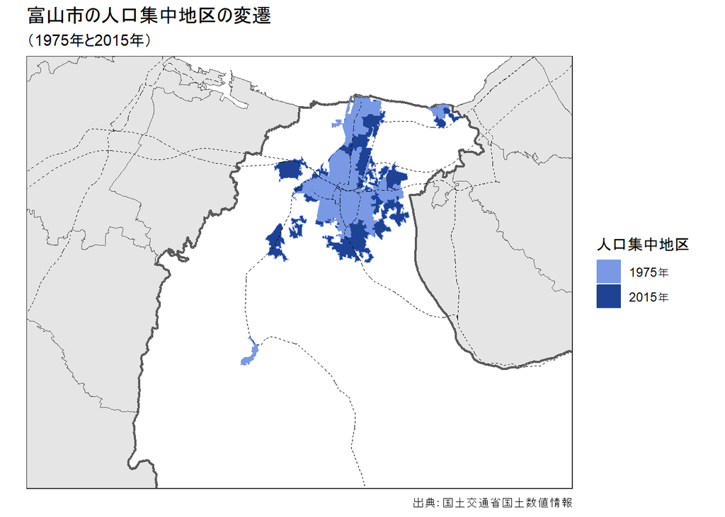

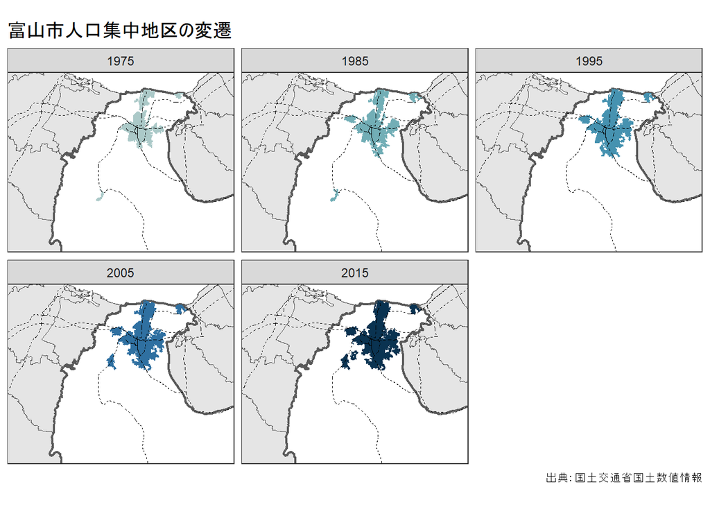

```r
#データ結合
DID <-
  rbind(Toyama_shi_DID75, Toyama_shi_DID85,
        Toyama_shi_DID95, Toyama_shi_DID05,
        Toyama_shi_DID15)

#列名A16_011（調査年）をyearと名付ける
DID %>%
  mutate(year=A16_011) ->
  DID

#可視化
ggplot()+
  geom_sf(data=Toyama_map)+
  geom_sf(data=Toyama_shi_map, linewidth=0.8,
          fill="white")+
   geom_sf(data=DID, aes(fill=year,
                        color=year))+
  scale_fill_met_d("Hokusai2")+
  scale_color_met_d("Hokusai2")+
  geom_sf(data=railway20, linewidth=0.2, linetype=2)+
  coord_sf(datum=NA,
           xlim= c(136.96, 137.4), ylim=c(36.5, 36.78))+
  labs(title="富山市人口集中地区の変遷",
       caption="出典：国土交通省国土数値情報")+
  facet_wrap(~year)+
  theme_bw()+
  theme(legend.position="none")
```

# アニメーション

年ごとに作成された地図（フレーム）を，アニメーション効果を用いて，可視化．

- 上で作成した地図の`facet_wrap(~year)`を削除．こうすることで，1975年の人口集中地区が一番下に配置され，順番に地図（フレーム＝コマ）が重なる．
- タイトルの下にサブタイトル（`subtitle`）を作成．`{current_frame}`は現在の地図（フレーム）の**西暦**が示される．
  - 地図名を`g`とする．

```r
g <-
  ggplot()+
  geom_sf(data=Toyama_map)+
  geom_sf(data=Toyama_shi_map, linewidth=0.8, fill="white")+
  geom_sf(data=DID, aes(fill=year,
                        color=year))+
  scale_fill_met_d("Hokusai2")+
  scale_color_met_d("Hokusai2")+
  geom_sf(data=railway20, linewidth=0.2, linetype=2)+
  coord_sf(datum=NA,
           xlim= c(136.96, 137.4), ylim=c(36.5, 36.78))+
  labs(title="富山市人口集中地区の変遷",
       subtitle="年:{current_frame}",
       caption="出典：国土交通省国土数値情報")+
  theme_bw()+
  theme(legend.position="none")
```

- `transition_manual(year)`：年ごとに作成された地図（フレーム）を連続して変化させるように指示．`anime`と名付ける．
- `animate()`：作成した`anime`をアニメ化．

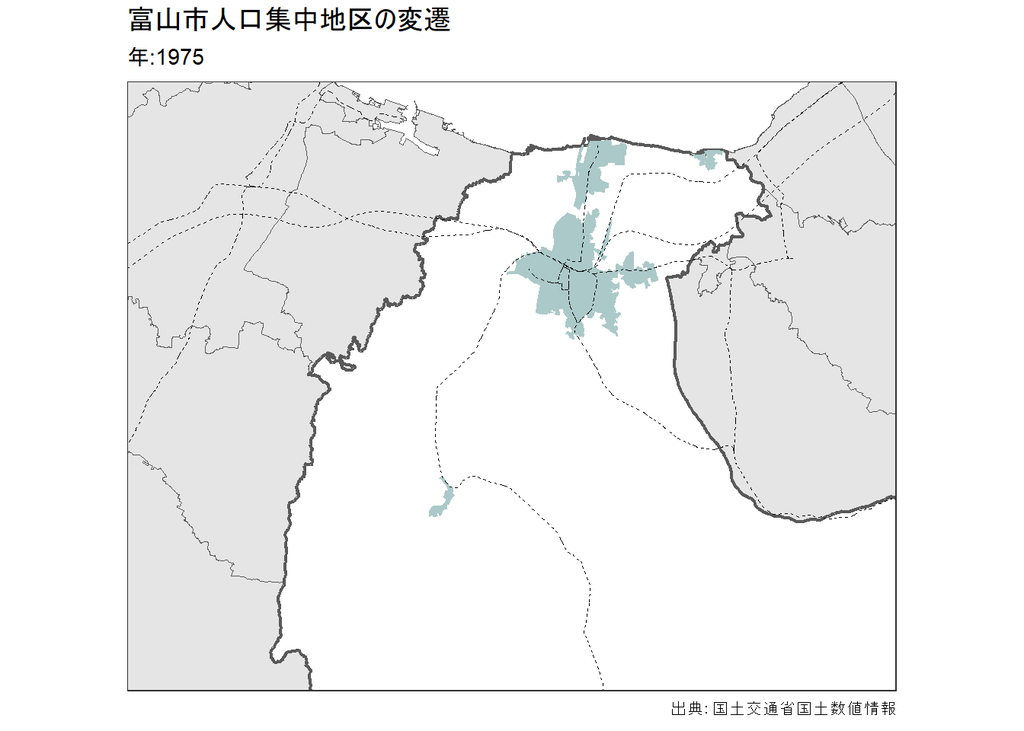

```r
anime <-
  g+transition_manual(year)

anime %>%
  animate()
```

## 参考（人口集中地区の人口密度の時系列変化）

↑で利用した人口集中地区のシェープファイルには人口集中地区の人口（人）や面積（㎢）が示されている．この数値から人口密度（人／㎢）が計算できる．

- ここでは，折れ線グラフを用いて人口密度の時系列変化を可視化．
  - ただし，各年重複する地域コードがあるため，事前に削除して（`distinct()`），新しいデータフレーム（`DID2`と名付ける）を作成．

```r
#重複するDIDid（地域コード）削除
#1975年
Toyama_shi_DID75 %>%
  distinct(A16_001,.keep_all=TRUE)->
  Toyama_shi_DID75
#1985年
Toyama_shi_DID85 %>%
  distinct(A16_001,.keep_all=TRUE)->
  Toyama_shi_DID85
#1995年
Toyama_shi_DID95 %>%
  distinct(A16_001,.keep_all=TRUE)->
  Toyama_shi_DID95
#2005年
Toyama_shi_DID05 %>%
  distinct(A16_001,.keep_all=TRUE)->
  Toyama_shi_DID05
#2015年
Toyama_shi_DID15 %>%
  distinct(A16_001,.keep_all=TRUE)->
  Toyama_shi_DID15

#データ結合
DID2 <-
  rbind(Toyama_shi_DID75, Toyama_shi_DID85,
        Toyama_shi_DID95, Toyama_shi_DID05,
        Toyama_shi_DID15)
```

- `A16_011`（調査年）を`year`と名付ける．
- `A16_005`（人口，単位人）を`pop`と名付け，整数型に．
- `A16_006`（面積，単位㎢）を`area`と名付け，（小数で表現されるため）実数型に．
  - 人口集中地区の人口密度を求めるため，総人口と総面積を計算．
  - 人口密度を`pop_den`と名付ける．
  - `pop_den`が格納されたファイルを`density`とする．

```r
#yearの作成，整数型
DID2 %>%
  mutate(year=A16_011,
         pop=as.integer(A16_005),
         area=as.numeric(A16_006)) ->
  DID2

DID2 %>%
    group_by(year) %>%
    summarise(pop=sum(pop),
              area=sum(area)) %>%
  mutate(pop_den=pop/area) ->
  density

#densityの中身
density
```

| year | pop | area | geometry | pop_den |
| --- | --- | --- | --- | --- |
| 1975 | 166572 | 32.00 | MULTIPOLYGON (((137.2023 36… | 5205.375 |
| 1985 | 197258 | 43.40 | MULTIPOLYGON (((137.1852 36… | 4545.115 |
| 1995 | 216764 | 51.30 | MULTIPOLYGON (((137.303 36…. | 4225.419 |
| 2005 | 218679 | 54.27 | MULTIPOLYGON (((137.1645 36… | 4029.464 |
| 2015 | 235868 | 57.89 | MULTIPOLYGON (((137.3036 36… | 4074.417 |

**折れ線グラフの完成図**

- `group=1`：すべてのデータポイント（1975年，85年，95年，2005年，15年の値）を同じグループとして扱うことを意味．これにより，データポイントが同じ線で結ばれる．

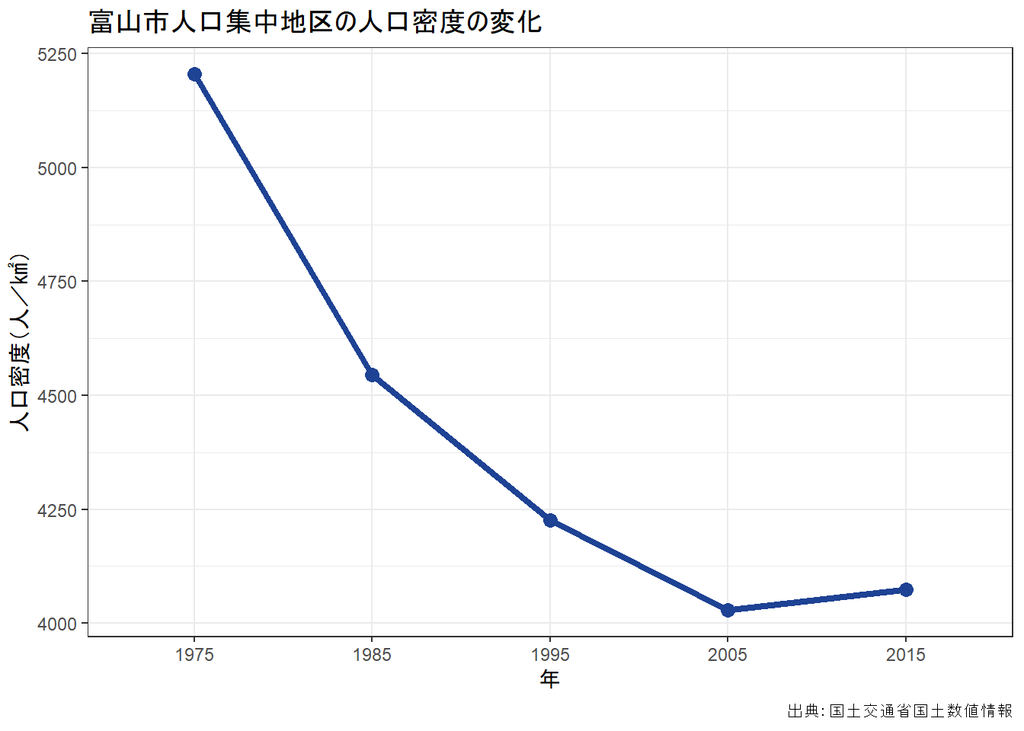

```r
#人口密度時系列図
ggplot()+
  geom_line(data=density,
            aes(x=year, y=pop_den, group=1),
            color="#1e4294", linewidth=1.5)+
  geom_point(data=density, aes(x=year, y=pop_den),
             color="#1e4294", fill="#1e4294", size=3)+
  labs(x="年", y="人口密度（人／㎢）",
      caption="出典：国土交通省国土数値情報")+
  ggtitle("富山市人口集中地区の人口密度の変化")+
  theme_bw()
```

**Rによる地理空間データの可視化**

- チュートリアル[ホーム](https://shinichiro-iwata.github.io/geospatial-data-visualization/)